# Midterm

Author

Katherine

**The data set I selected for this project is the COVID-19 Vaccination data set from the World Health Organization (WHO), which compiles information originally collected through the University of Maryland Global COVID-19 Trends and Impact Survey (UMD-CTIS) in partnership with Facebook. This global survey was conducted from April 23, 2020, to June 25, 2022, with the final data set released in April 2023. The UMD-CTIS collected data on a range of topics including burden, mental health, beliefs and behaviors, financial worry, information, testing, and vaccine coverage and hesitancy.The data are disaggreated by age, gender, education, health worker status, and place of residence. I figure this data is useful in finding out inequalities in vaccine access and uptake across populations.**

**Main Question: Is COVID-19 vaccine associated with education level across different countries?**

#Read in the data

```r
# Load the library
library(readxl)
data <- read_excel("/Users/gongxinyu/Downloads/rep_ctis2/data.xlsx")
```

#Data exploratory

```r
library(tidyr)
library(dplyr)
data %>%
  filter(population > 13e9) %>%
  select(setting, iso3, date, indicator_name, dimension, subgroup, population)
```

```
# A tibble: 1 × 7
  setting iso3  date    indicator_name             dimension subgroup population
  <chr>   <chr> <chr>   <chr>                      <chr>     <chr>         <dbl>
1 India   IND   2022-01 Self-reported receipt of … Gender    Male        1.30e10
```

```r
data %>%
  group_by(dimension) %>%
  summarise(unique_subgroups = list(unique(subgroup))) %>%
  unnest(cols = c(unique_subgroups)) %>%
  arrange(dimension)
```

```
# A tibble: 19 × 2
   dimension               unique_subgroups
   <chr>                   <chr>
 1 Age (4 groups) (18-65+) 18-24 years
 2 Age (4 groups) (18-65+) 25-44 years
 3 Age (4 groups) (18-65+) 45-64 years
 4 Age (4 groups) (18-65+) 65+ years
 5 Education (4 groups)    Four-year degree
 6 Education (4 groups)    Less than secondary education
 7 Education (4 groups)    Postgraduate education
 8 Education (4 groups)    Secondary education
 9 Education (5 groups)    1-6 years of education
10 Education (5 groups)    13-15 years of education
11 Education (5 groups)    16-30 years of education
12 Education (5 groups)    7-12 years of education
13 Education (5 groups)    No education
14 Gender                  Female
15 Gender                  Male
16 Health worker status    Health worker
17 Health worker status    Not health worker
18 Place of residence      Rural
19 Place of residence      Urban
```

**One important variable is estimate (which is tells about the % of vaccinated, % of vaccinated, % of who is hesitate to get vaccine due to cost, etc). Other important variables are subgroup and dimension. Age is categorized into four unique groups (18–24 years, 25–44 years, 45–64 years, and 65+ years). Education appears in two forms, depending on the survey period: one version divides respondents by education level into four subgroups (less than secondary education, secondary education, four-year degree, and postgraduate education), while the other measures years of schooling completed with five subgroups (no education, 1–6 years, 7–12 years, 13–15 years, and 16–30 years). Gender includes two subgroups, male and female. Place of residence distinguishes between urban and rural based on self-reported.**

#Visualize the disturbution of key variables

```r
library(ggplot2)
library(stringr)
library(forcats)
data_clean <- data %>%
  filter(!is.na(estimate), estimate >= 0, estimate <= 100) %>%
  #mutate(new_column = some_transformation(old_column))
  mutate(indicator_short = str_wrap(indicator_name, width = 35)) #create new column "indicator_short"
```

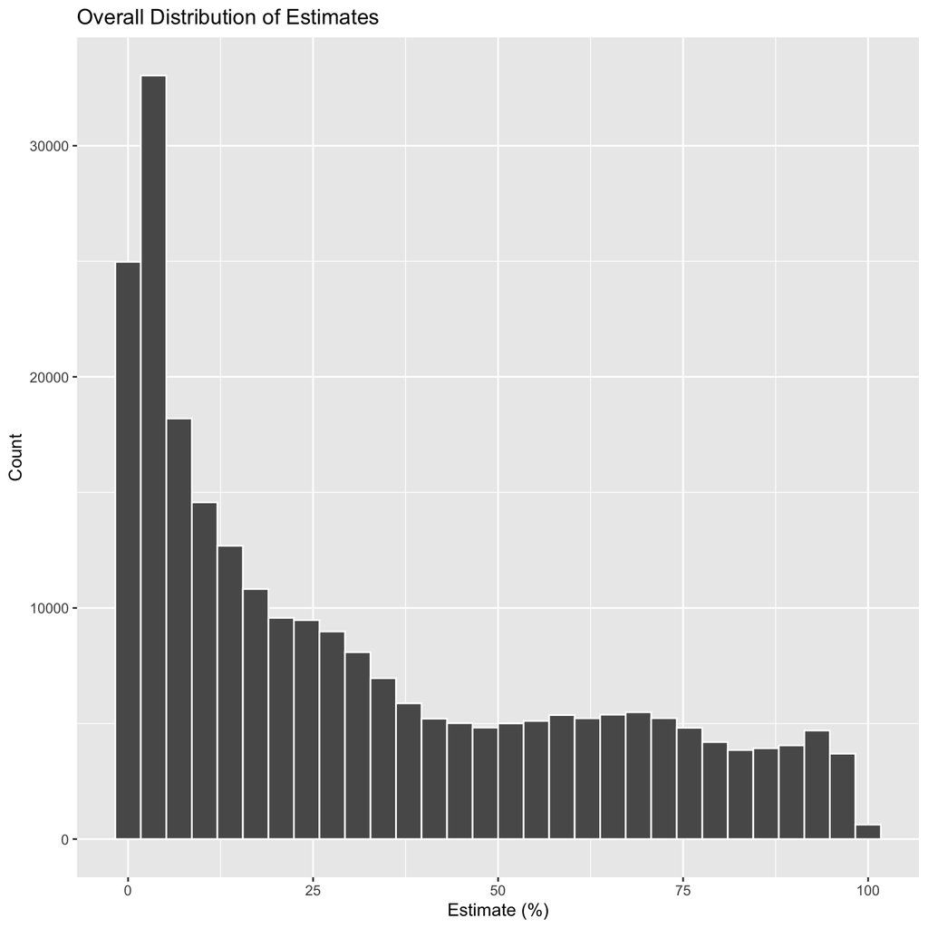

```r
ggplot(data_clean, aes(x = estimate)) +
  geom_histogram(color = "white") +
  labs(title = "Overall Distribution of Estimates",
       x = "Estimate (%)", y = "Count")
```

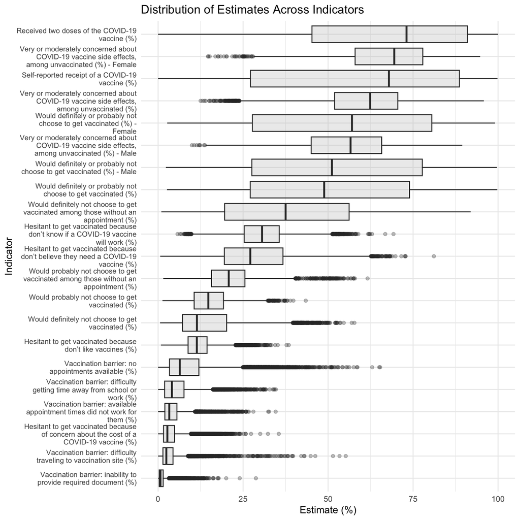

```r
ggplot(data_clean,
       aes(y = fct_reorder(indicator_short, estimate, .fun = median), #reorder by median
           x = estimate)) +
  geom_boxplot(alpha = 0.3, fill = "grey") +
  labs(title = "Distribution of Estimates Across Indicators",
       x = "Estimate (%)", y = "Indicator") +
  theme_minimal(base_size = 11) +
  theme(axis.text.y = element_text(size = 8))
```

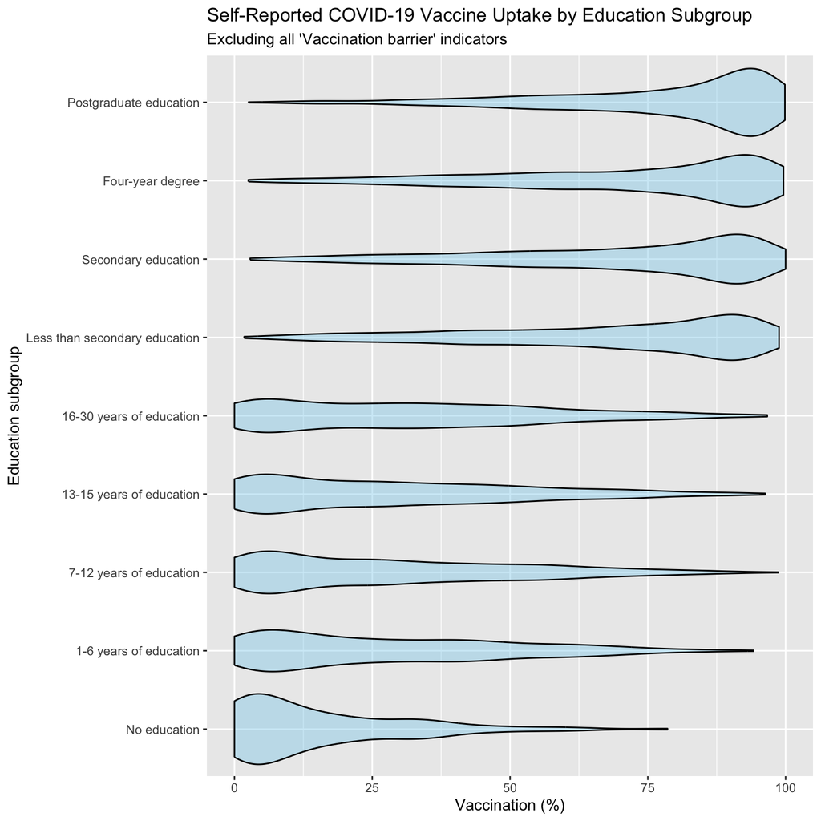

```r
 vaccine_edu <- data_clean %>%
  filter(
    indicator_name %in% c("Self-reported receipt of a COVID-19 vaccine (%)",
                          "Received two doses of the COVID-19 vaccine (%)"),
    grepl("Education", dimension, ignore.case = TRUE), #include
    !grepl("barrier", indicator_name, ignore.case = TRUE)  # remove vaccine barrier
  ) %>%
  mutate(subgroup = fct_reorder(subgroup, estimate))

ggplot(vaccine_edu, aes(x = subgroup, y = estimate)) +
  geom_violin(fill = "skyblue", color = "black", alpha = 0.4) +
  coord_flip() +
  labs(
    title = "Self-Reported COVID-19 Vaccine Uptake by Education Subgroup",
    subtitle = "Excluding all 'Vaccination barrier' indicators",
    x = "Education subgroup",
    y = "Vaccination (%)"
  )
```

**We see a right skewed distribution for estimate, so I use median to reorder the data. From the indicator short (indicator name), we can see that there are still many people choose to getting two doses of vaccine or self reported getting COVID-19 vaccine. Then we address my primary question I made a violin plot between estimate of self-reported receipt of a COVID-19 vaccine (%) and received two doses of the COVID-19 vaccine (%) as my group of being vaccinated and plot is against education subgroup. From this plot, it indicates a positive association between education level and vaccination uptake. Participants with higher education show higher vaccination rates, and this could due to increased knowledge of public health, awareness of disease prevention strategies, and knowledge in how vaccine works. After finding out the answer for my primary question, I now what to know is getting vaccine related to health worker status, age and income level.**

#Future question – What is the relationship between health worker status, age, place of residence, and income level with vaccine status?

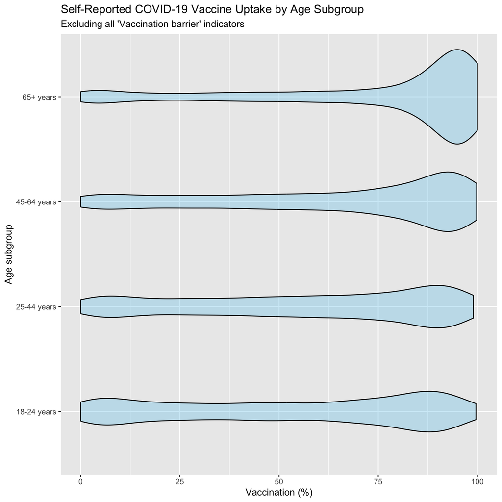

```r
#Age VS Vaccine status
Age <- data_clean %>%
  filter(
    indicator_name %in% c("Self-reported receipt of a COVID-19 vaccine (%)",
                          "Received two doses of the COVID-19 vaccine (%)"),
    grepl("Age", dimension, ignore.case = TRUE), #include
    !grepl("barrier", indicator_name, ignore.case = TRUE)  # remove vaccine barrier
  ) %>%
  mutate(subgroup = fct_reorder(subgroup, estimate))

ggplot(Age, aes(x = subgroup, y = estimate)) +
  geom_violin(fill = "skyblue", color = "black", alpha = 0.4) +
  coord_flip() +
  labs(
    title = "Self-Reported COVID-19 Vaccine Uptake by Age Subgroup",
    subtitle = "Excluding all 'Vaccination barrier' indicators",
    x = "Age subgroup",
    y = "Vaccination (%)"
  )
```

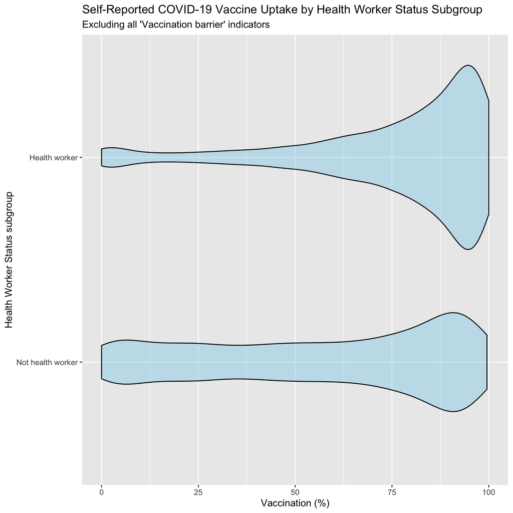

```r
#Health worker status VS Vaccine status
Health <- data_clean %>%
  filter(
    indicator_name %in% c("Self-reported receipt of a COVID-19 vaccine (%)",
                          "Received two doses of the COVID-19 vaccine (%)"),
    grepl("Health worker", dimension, ignore.case = TRUE), #include
    !grepl("barrier", indicator_name, ignore.case = TRUE)  # remove vaccine barrier
  ) %>%
  mutate(subgroup = fct_reorder(subgroup, estimate))

ggplot(Health, aes(x = subgroup, y = estimate)) +
  geom_violin(fill = "skyblue", color = "black", alpha = 0.4) +
  coord_flip() +
  labs(
    title = "Self-Reported COVID-19 Vaccine Uptake by Health Worker Status Subgroup",
    subtitle = "Excluding all 'Vaccination barrier' indicators",
    x = "Health Worker Status subgroup",
    y = "Vaccination (%)"
  )
```

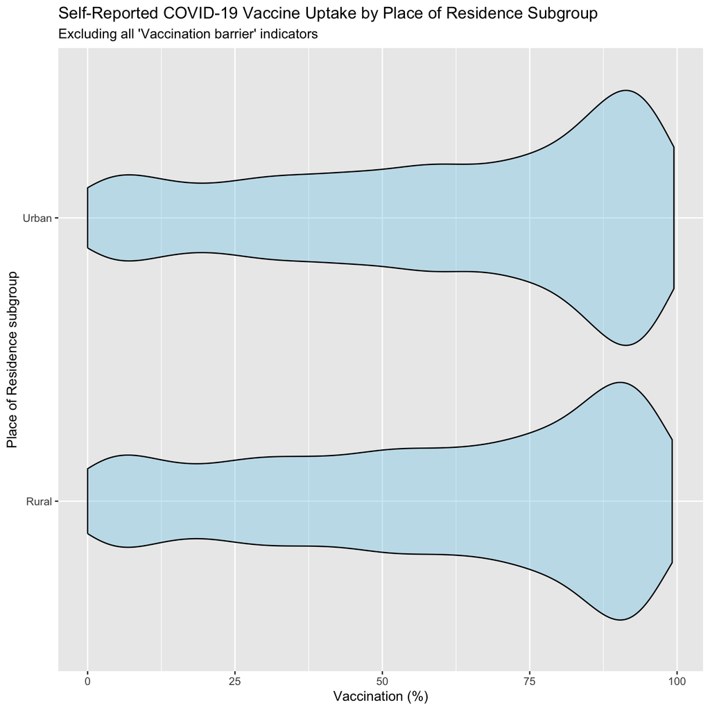

```r
#place of residence Vs vaccine status
place <- data_clean %>%
  filter(
    indicator_name %in% c("Self-reported receipt of a COVID-19 vaccine (%)",
                          "Received two doses of the COVID-19 vaccine (%)"),
    grepl("resident", dimension, ignore.case = TRUE)|
      grepl("urban|rural", subgroup, ignore.case = TRUE),
    !grepl("barrier", indicator_name, ignore.case = TRUE)  # remove vaccine barrier
  ) %>%
  mutate(subgroup = fct_reorder(subgroup, estimate))

ggplot(place, aes(x = subgroup, y = estimate)) +
  geom_violin(fill = "skyblue", color = "black", alpha = 0.4) +
  coord_flip() +
  labs(
    title = "Self-Reported COVID-19 Vaccine Uptake by Place of Residence Subgroup",
    subtitle = "Excluding all 'Vaccination barrier' indicators",
    x = "Place of Residence subgroup",
    y = "Vaccination (%)"
  )
```

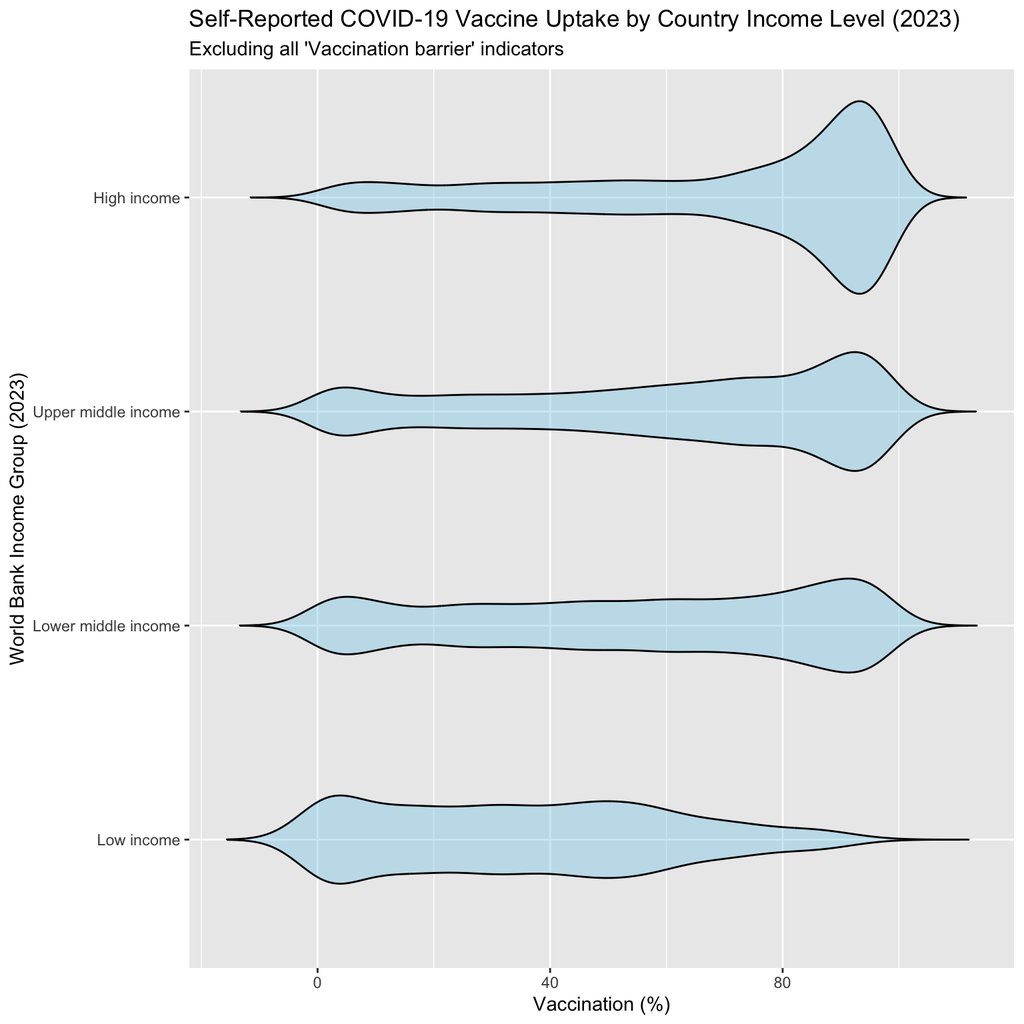

```r
# Income Vs Vaccine status
income <- data_clean %>%
  filter(
    indicator_name %in% c(
      "Self-reported receipt of a COVID-19 vaccine (%)",
      "Received two doses of the COVID-19 vaccine (%)"
    ),
    !grepl("barrier", indicator_name, ignore.case = TRUE),
    !is.na(wbincome2023)
  ) %>%
  mutate(
    wbincome2023 = fct_relevel(  #sets the order of those factor levels manually
      as.factor(wbincome2023), #convert to factor (catergorical variable)
      "Low income",
      "Lower middle income",
      "Upper middle income",
      "High income"
    )
  )

ggplot(income, aes(x = wbincome2023, y = estimate)) +
  geom_violin(fill = "skyblue", color = "black", alpha = 0.4, trim = FALSE) +
  coord_flip() +
  labs(
    title = "Self-Reported COVID-19 Vaccine Uptake by Country Income Level (2023)",
    subtitle = "Excluding all 'Vaccination barrier' indicators",
    x = "World Bank Income Group (2023)",
    y = "Vaccination (%)"
  )
```

**We can see that older individuals tend to have higher vaccination rates. This pattern is expected, as older adults are more likely to have underlying health conditions that could lead to severe or even fatal outcomes if they become infected. The elderly population is also the group most often prioritized for vaccination campaigns.Among younger age groups, vaccination rates appear to be relatively even, showing no strong differences in uptake.**

**Health workers have higher vaccination rates compared with non–health workers, which makes sense given their greater exposure to infectious diseases and the need to protect both themselves and their patients.When comparing place of residence, vaccination percentages are similar between rural and urban areas, suggesting limited disparity based on location. However, income level shows a clearer pattern: high-income countries have a greater tendency toward vaccination than lower-income countries. The upper-middle-income and lower-middle-income groups show similar patterns, though the upper-middle-income group demonstrates a slightly stronger tendency to be vaccinated.**